# Accelerometer Data Analysis and Prediction

2024-01-17

#Overview In this project, we will use data from accelerometers on the belt, forearm, arm, and dumbell of 6 participants to predict the manner in which they did the exercise. This is the “classe” variable in the training set. We train 3 models: Decision Tree, Random Forest, Support Vector Machine using k-folds cross validation on the training set. We then predict using a validation set randomly selected from the training csv data to obtain the accuracy and out of sample error rate. Based on those numbers, we decide on the best model, and use it to predict 20 cases using the test csv set.

#Background Using devices such as Jawbone Up, Nike FuelBand, and Fitbit it is now possible to collect a large amount of data about personal activity relatively inexpensively. These type of devices are part of the quantified self movement - a group of enthusiasts who take measurements about themselves regularly to improve their health, to find patterns in their behavior, or because they are tech geeks. One thing that people regularly do is quantify how much of a particular activity they do, but they rarely quantify how well they do it. In this project, the goal will be to use data from accelerometers on the belt, forearm, arm, and dumbell of 6 participants. They were asked to perform barbell lifts correctly and incorrectly in 5 different ways.

The training data for this project are available here:

https://d396qusza40orc.cloudfront.net/predmachlearn/pml-training.csv

The test data are available here:

https://d396qusza40orc.cloudfront.net/predmachlearn/pml-testing.csv

#Data Processing ##Loading Necessary Libraries

```r
# Load Libraries
library(caret)
```

```r
library(rpart)
library(rpart.plot)
library(randomForest)
library(corrplot)
library(ggplot2)
```

##Loading Data

```r
# read data from csv files
train <- read.csv("pml-training.csv", na.strings=c("NA","#DIV/0!",""))
test <- read.csv("pml-testing.csv", na.strings=c("NA","#DIV/0!",""))

head(train,n=5)
```

```
##   X user_name raw_timestamp_part_1 raw_timestamp_part_2   cvtd_timestamp
## 1 1  carlitos           1323084231               788290 05/12/2011 11:23
## 2 2  carlitos           1323084231               808298 05/12/2011 11:23
## 3 3  carlitos           1323084231               820366 05/12/2011 11:23
## 4 4  carlitos           1323084232               120339 05/12/2011 11:23
## 5 5  carlitos           1323084232               196328 05/12/2011 11:23
##   new_window num_window roll_belt pitch_belt yaw_belt total_accel_belt
## 1         no         11      1.41       8.07    -94.4                3
## 2         no         11      1.41       8.07    -94.4                3
## 3         no         11      1.42       8.07    -94.4                3
## 4         no         12      1.48       8.05    -94.4                3
## 5         no         12      1.48       8.07    -94.4                3
##   kurtosis_roll_belt kurtosis_picth_belt kurtosis_yaw_belt skewness_roll_belt
## 1                 NA                  NA                NA                 NA
## 2                 NA                  NA                NA                 NA
```

[output cut: 213 more lines]

```r
head(test,n=5)
```

```
##   X user_name raw_timestamp_part_1 raw_timestamp_part_2   cvtd_timestamp
## 1 1     pedro           1323095002               868349 05/12/2011 14:23
## 2 2    jeremy           1322673067               778725 30/11/2011 17:11
## 3 3    jeremy           1322673075               342967 30/11/2011 17:11
## 4 4    adelmo           1322832789               560311 02/12/2011 13:33
## 5 5    eurico           1322489635               814776 28/11/2011 14:13
##   new_window num_window roll_belt pitch_belt yaw_belt total_accel_belt
## 1         no         74    123.00      27.00    -4.75               20
## 2         no        431      1.02       4.87   -88.90                4
## 3         no        439      0.87       1.82   -88.50                5
## 4         no        194    125.00     -41.60   162.00               17
## 5         no        235      1.35       3.33   -88.60                3
##   kurtosis_roll_belt kurtosis_picth_belt kurtosis_yaw_belt skewness_roll_belt
## 1                 NA                  NA                NA                 NA
## 2                 NA                  NA                NA                 NA
```

[output cut: 213 more lines]

```r
names(train)
```

```
##   [1] "X"                        "user_name"
##   [3] "raw_timestamp_part_1"     "raw_timestamp_part_2"
##   [5] "cvtd_timestamp"           "new_window"
##   [7] "num_window"               "roll_belt"
##   [9] "pitch_belt"               "yaw_belt"
##  [11] "total_accel_belt"         "kurtosis_roll_belt"
##  [13] "kurtosis_picth_belt"      "kurtosis_yaw_belt"
##  [15] "skewness_roll_belt"       "skewness_roll_belt.1"
##  [17] "skewness_yaw_belt"        "max_roll_belt"
##  [19] "max_picth_belt"           "max_yaw_belt"
##  [21] "min_roll_belt"            "min_pitch_belt"
##  [23] "min_yaw_belt"             "amplitude_roll_belt"
##  [25] "amplitude_pitch_belt"     "amplitude_yaw_belt"
##  [27] "var_total_accel_belt"     "avg_roll_belt"
##  [29] "stddev_roll_belt"         "var_roll_belt"
```

[output cut: 65 more lines]

```r
dim(train)
```

```
## [1] 19622   160
```

```r
dim(test)
```

```
## [1]  20 160
```

The dataset contains a lot of NA and missing values , therefore it is necessary to perform some data cleaning before proceeding with the training of models.

##Data Cleaning

```r
# Clean dataset by removing rows and columns with missing values
trainClean <- train[, colSums(is.na(train)) == 0]
testClean <- test[, colSums(is.na(test)) == 0]

trainClean <- trainClean[,-c(1:7)] #removing metadata which is irrelevant to the outcome
nearZeroVar(trainClean) # no variable with near zero variance
```

```
## integer(0)
```

Now that the data is clean and has all the unwanted variables removed, we can split the data for training the model.

```r
# split data into train and test from the training set
set.seed(42)
inTrain <- createDataPartition(y=trainClean$classe, p=0.6, list=FALSE)
myTrain <- trainClean[inTrain, ]
myTest <- trainClean[-inTrain, ]
dim(myTrain)
```

```
## [1] 11776    53
```

```r
dim(myTest)
```

```
## [1] 7846   53
```

```r
# setting control variable for 4 fold cross validation
control <- trainControl(method="cv", number=4, verboseIter=F)
```

###1.Decision Trees

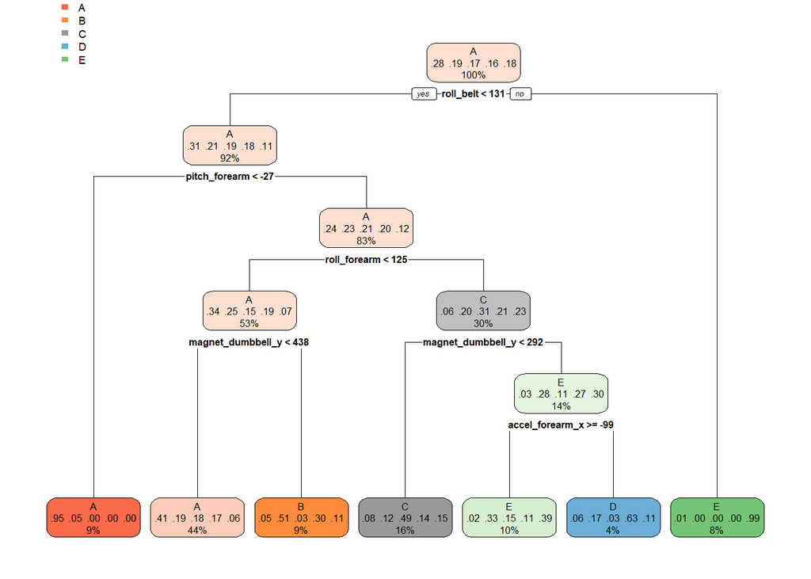

```r
# Fitting Decision Tree Model
mod1 <- train(classe~., data=myTrain, method="rpart", trControl = control, tuneLength = 5)
rpart.plot(mod1$finalModel)
```

```r
pred1 <- predict(mod1, myTest)
cm1 <- confusionMatrix(pred1, factor(myTest$classe))
cm1
```

```
## Confusion Matrix and Statistics
##
##           Reference
## Prediction    A    B    C    D    E
##          A 2027  639  665  576  224
##          B   33  389   20  215   88
##          C  115  165  574  178  153
##          D   21   56   12  241   46
##          E   36  269   97   76  931
##
## Overall Statistics
##
##                Accuracy : 0.5305
##                  95% CI : (0.5193, 0.5416)
##     No Information Rate : 0.2845
##     P-Value [Acc > NIR] : < 2.2e-16
##
##                   Kappa : 0.3859
##
##  Mcnemar's Test P-Value : < 2.2e-16
##
## Statistics by Class:
##
##                      Class: A Class: B Class: C Class: D Class: E
## Sensitivity            0.9082  0.25626  0.41959  0.18740   0.6456
## Specificity            0.6252  0.94374  0.90568  0.97942   0.9254
## Pos Pred Value         0.4907  0.52215  0.48439  0.64096   0.6608
## Neg Pred Value         0.9448  0.84101  0.88080  0.86011   0.9206
## Prevalence             0.2845  0.19347  0.17436  0.16391   0.1838
## Detection Rate         0.2583  0.04958  0.07316  0.03072   0.1187
## Detection Prevalence   0.5265  0.09495  0.15103  0.04792   0.1796
## Balanced Accuracy      0.7667  0.60000  0.66264  0.58341   0.7855
```

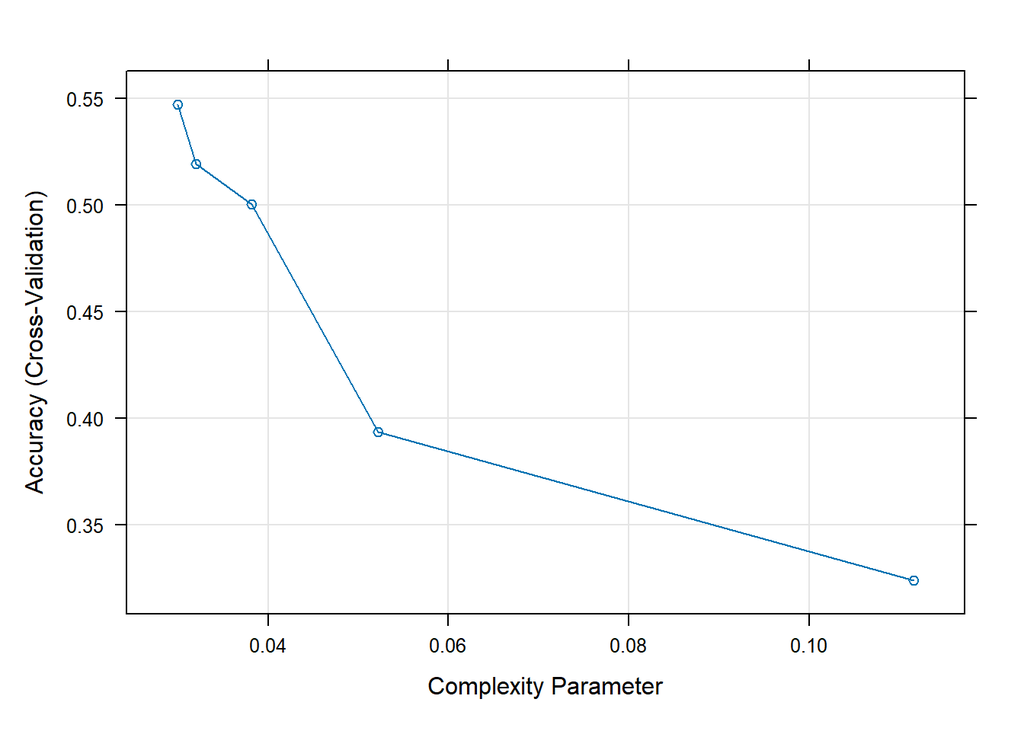

```r
plot(mod1)
```

###2.Random Forest

```r
# Fitting Random Forest Model
mod2 <- train(classe~., data=myTrain, method="rf", trControl = control, tuneLength = 5)
pred2 <- predict(mod2, myTest)
cm2 <- confusionMatrix(pred2, factor(myTest$classe))
cm2
```

```
## Confusion Matrix and Statistics
##
##           Reference
## Prediction    A    B    C    D    E
##          A 2226    9    0    0    0
##          B    5 1508    9    0    0
##          C    1    1 1355    8    0
##          D    0    0    4 1273    1
##          E    0    0    0    5 1441
##
## Overall Statistics
##
##                Accuracy : 0.9945
##                  95% CI : (0.9926, 0.996)
##     No Information Rate : 0.2845
##     P-Value [Acc > NIR] : < 2.2e-16
##
##                   Kappa : 0.9931
##
##  Mcnemar's Test P-Value : NA
##
## Statistics by Class:
##
##                      Class: A Class: B Class: C Class: D Class: E
## Sensitivity            0.9973   0.9934   0.9905   0.9899   0.9993
## Specificity            0.9984   0.9978   0.9985   0.9992   0.9992
## Pos Pred Value         0.9960   0.9908   0.9927   0.9961   0.9965
## Neg Pred Value         0.9989   0.9984   0.9980   0.9980   0.9998
## Prevalence             0.2845   0.1935   0.1744   0.1639   0.1838
## Detection Rate         0.2837   0.1922   0.1727   0.1622   0.1837
## Detection Prevalence   0.2849   0.1940   0.1740   0.1629   0.1843
## Balanced Accuracy      0.9979   0.9956   0.9945   0.9946   0.9993
```

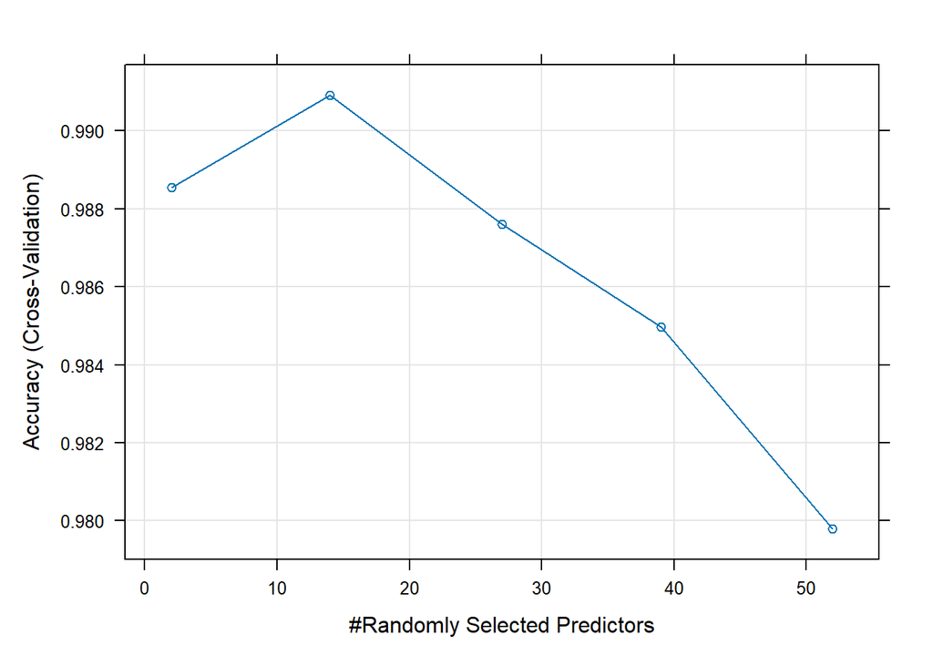

```r
plot(mod2)
```

###2.Support Vector Machine

```r
# Fitting SVM Model
mod3 <- train(classe~., data=myTrain, method="svmLinear", trControl = control, tuneLength = 5, verbose = F)
pred3 <- predict(mod3, myTest)
cm3 <- confusionMatrix(pred3, factor(myTest$classe))
cm3
```

```
## Confusion Matrix and Statistics
##
##           Reference
## Prediction    A    B    C    D    E
##          A 2072  206  116   85   70
##          B   43 1086  129   50  183
##          C   57   77 1064  134  108
##          D   51   39   31  958   68
##          E    9  110   28   59 1013
##
## Overall Statistics
##
##                Accuracy : 0.7893
##                  95% CI : (0.7801, 0.7983)
##     No Information Rate : 0.2845
##     P-Value [Acc > NIR] : < 2.2e-16
##
##                   Kappa : 0.7321
##
##  Mcnemar's Test P-Value : < 2.2e-16
##
## Statistics by Class:
##
##                      Class: A Class: B Class: C Class: D Class: E
## Sensitivity            0.9283   0.7154   0.7778   0.7449   0.7025
## Specificity            0.9150   0.9360   0.9420   0.9712   0.9678
## Pos Pred Value         0.8129   0.7284   0.7389   0.8352   0.8310
## Neg Pred Value         0.9698   0.9320   0.9525   0.9510   0.9353
## Prevalence             0.2845   0.1935   0.1744   0.1639   0.1838
## Detection Rate         0.2641   0.1384   0.1356   0.1221   0.1291
## Detection Prevalence   0.3249   0.1900   0.1835   0.1462   0.1554
## Balanced Accuracy      0.9217   0.8257   0.8599   0.8581   0.8352
```

##Comparative Analysis Now, we will compare the accuracy and Out of Sample Error for all the three models

```r
# Compile Model Results
ModelName <- c("Decision Tree","Random Forest","SVM")
OOSE <- c(1 - as.numeric(cm1$overall[1]),1 - as.numeric(cm2$overall[1]),1 - as.numeric(cm3$overall[1]))
Accuracy <- c(0.5442,0.9944,0.7822)
Model_Summary <- data.frame(ModelName,Accuracy,OOSE)
Model_Summary
```

[output not shown]

It can be observed that Random Forest model performs the best with the highest accuracy of 99.44%. Therefore, it is chosen as the best model for this dataset and the prediction on testing dataset will be performed using the Random Forest Model

```r
# Prediction on Tests set
pred <- predict(mod2, testClean)
print(pred)
```

```
##  [1] B A B A A E D B A A B C B A E E A B B B
## Levels: A B C D E
```